# Demonstration of the smacpod package

## Introduction

The **smacpod** package implements methods for analyzing case-control point pattern data. It relies on the **spatstat** package for many of the internal computations, and many function arguments are simply the relevant arguments of a **spatstat** function.

We briefly summarize functionality below using the `grave` data set. The `grave` data set provides information related to 143 medieval grave locations. 30 of the graves are `"affected"` by a tooth deformity, while the remaining graves are `"unaffected"` by the deformity. The `grave` data set is a `ppp` object, which is a class utilized by the **spatstat** package.

We load and plot the data to start.

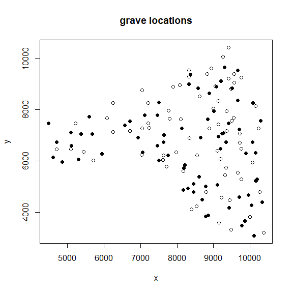

```r
# load packages
library(smacpod)
data(grave)
# pch changes point symbol
plot(grave, pch = c(1, 19), main = "grave locations", xlab = "x", ylab = "y")
```

## Spatial density

The `spdensity` function computes the spatial density function of a point pattern. The **spatstat** package provides a `density` function, which is actually the estimated intensity of a point pattern. The `spdensity` function scales the intensity to integrate to 1. The result is an `im` object, a class from the **spatstat** package, which has an associated `plot` method. We estimate and plot the spatial density of the `affected` grave locations below. We do not specify the bandwidth or kernel function used in the estimation process, so the default choices of the **spatstat** package are used. The heat map of the estimated spatial density indicates greater density of grave locations in the lower right part of the study area.

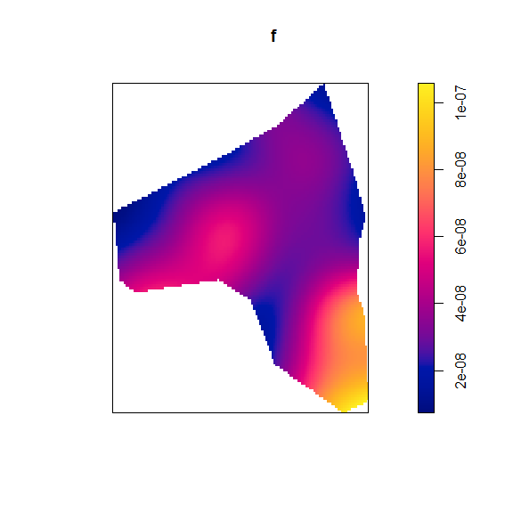

```r
# identify affected observations
aff <- (grave$marks == "affected")
# estimated spatial density function for affected observations
f <- spdensity(grave[aff,])
# plot spatial density function of affected
plot(f, "spatial density of affected graves")
```

# Log relative risk

Let $D$ denote the study area under consideration. Let $\lambda_1(s)$ denote the intensity function at location $s$ of the group designated as the `case` group. Then the spatial density of the `case` group can be denoted as
$$f(s)=\frac{\lambda_1(s)}{\int_D \lambda_1(s)
ds}.$$
Similarly the intensity function and spatial denstiy function of the `control` group are denoted as $\lambda_0(s)$ and $g(s)$, respectively.

The log relative risk function is defined as
$$r(s) =
\ln\left(\frac{f(s)}{g(s)}\right).$$
The log relative risk function can be estimated by
$$\hat{r}(s) =
\ln\left(\frac{\hat{f}(s)}{\hat{g}(s)}\right),$$
where $\hat{f}$ and $\hat{g}$ are the estimates of $f$ and $g$ from the `spdensity` function.

The log relative risk can be estimated using the `logrr` function. The function takes:

- `x`: a `ppp` object with `marks` for the cases and controls
- `sigma`: the bandwidth parameter of the `case` group
- `sigmacon`: the bandwidth parameter of the control group
- `case`: a character string specifying the name of the case group or the index of the case group in `levels(x$marks)`. The default is `case = 2`, the second level of `x$marks`.

If `sigma` and `sigmacon` aren’t specified, then the `spatstat.explore::bw.relrisk` function is used for these arguments.

```r
rhat <- logrr(grave, case = "affected")
```

```
## affected has been selected as the case group
```

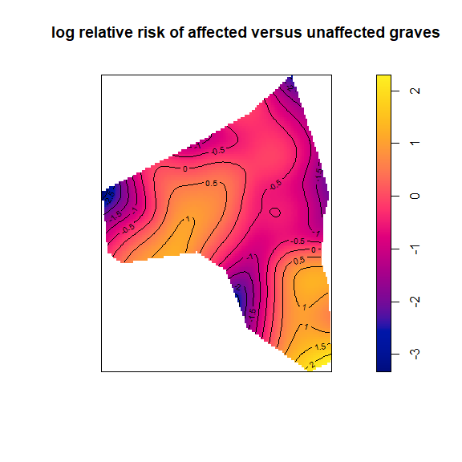

```r
plot(rhat, main = "log relative risk of affected versus unaffected graves")
contour(rhat, add = TRUE)
```

If the ratio $f(s)/g(s)$ is constant, then the relative risk is 1 and $r(s)=0$. To determine where the log relative risk differs significantly from zero, we can simulate `nsim` new case-control data sets under the random labeling hypothesis, estimate $r(s)$ for each simulated data set, and construct tolerance envelopes for $r(s)$ at each location. If $\hat{r}(s)$ is outside the tolerance envelopes, then the estimated log relative risk is inconsistent with $r(s)=0$ under the random labeling hypothesis. This is the same is believing the spatial densities of the cases and controls differ from zero at that location. If the spatial density of the cases is greater than the spatial density of the controls, then we believe there is a cluster of cases relative to the controls. If the spatial density of the controls is greater than the spatial density of the cases, then we believe there is a cluster of controls relative to the cases. The tolerance envelopes can be constructed by specifying the following arguments of `logrr`:

- `nsim`: the number of randomly labeled data sets to generate.
- `level`: the level of the tolerance envelopes. The default is `0.90`.
- `alternative`: the type of envelopes to construct. The default is `two.sided`.

When `nsim>0`, the `logrr` function returns an object of class `renv`, which has a `plot` method that makes it easy to identify the parts of the study area where the estimated log relative risk is outside the tolerance envelopes. Any colored area indicates a location where the log relative risk is outside the tolerance envelopes. Non-colored areas indicate the estimated log relative risk is inside the tolerance envelopes.

Similarly, there is a `print` method for the `renv` class summarizing information about the object constructed.

For the `grave` data, the yellow areas indicate parts of the study area where the `affected` grave locations are clustered relative to the `unaffected` grave locations beyond what is expected under the random labeling hypothesis. The purple areas indicate parts of the study area where the `unaffected` grave locations are clustered relative to the `affected` grave locations beyond what is expected under the random labeling hypothesis.

```r
# construct tolerance envelopes for logrr
renv = logrr(grave, case = "affected", nsim = 99, level = 0.90)
```

```
## affected has been selected as the case group
```

```r
# print info for tolerance envelopes
renv
```

```
##
## pixelwise tolerance envelopes for log relative risk, r(s)
##
## r(s) = ln[f(s)/g(s)]
## f(s) = spatial density of cases at location s
## g(s) = spatial density of controls at location s
## case label:  affected
## control label:  unaffected
## number of simulations: 99
## simulation procedure: random labeling
## envelope level:  0.9
```

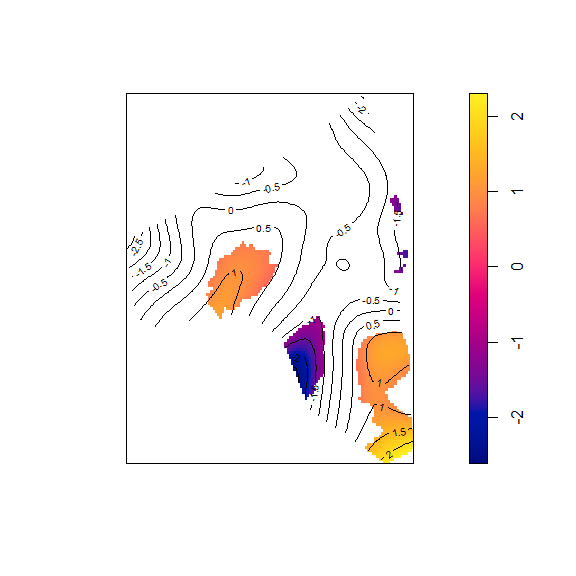

```r
# plot areas with rhat outside of envelopes
plot(renv)
```

The color scale can be manipulated to use different colors, as in the example below.

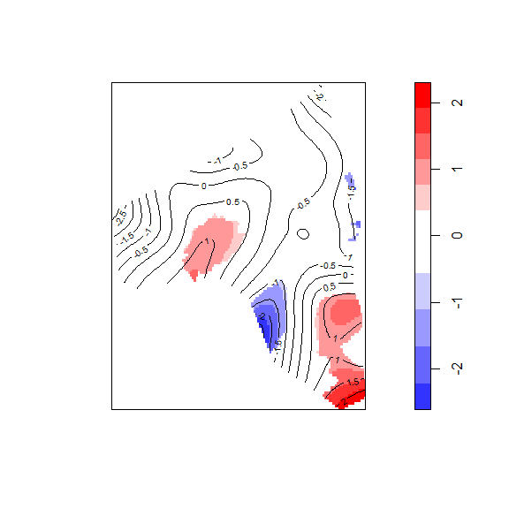

```r
# a better color scale (in my opinion)
# making it easier to distinguish the clusters of cases relative
# to controls (red) and vice versa (blue)
grad = gradient.color.scale(min(renv$v, na.rm = TRUE), max(renv$v, na.rm = TRUE))
plot(renv, col = grad$col, breaks = grad$breaks)
```

Because the tolerance envelopes do not account for multiple comparisons, Kelsall and Diggle (1995) proposed a test of

$H_0: r(s) = 0$ for all $s$ in $D$

$H_a: r(s) \neq 0$ for at least one $s$ in $D$

using the test statistic $\int_D \{\hat{r}(s)\}^2\,ds$.

This test is implemented in the `logrr.test` function, which takes an object of class `renv`.

For the `grave` data, since the p-value is relative large, there isn’t convincing evidence that the log relative risk of the affected and unaffected grave locations differs from 0 for at least one location in the study area.

```r
logrr.test(renv)
```

```
##
## Kelsall and Diggle (1995) test for log relative risk
##
## r(s) = ln[f(s)/g(s)]
## f(s) = spatial density of cases at location s
## g(s) = spatial density of controls at location s
## case label:  affected
## control label:  unaffected
##
## null hypothesis: r(s) = 0 for all s in study area
## alternative hypothesis: r(s) != 0 for at least one s in study area
## test statistic: 19478034
## p-value: 0.22
## nsim: 99
## simulation procedure: random labeling
```

## Difference in K functions

Ripley’s K function is often used to assess the variability of the distances between events for point patterns. A difference in K functions can be used to compare the clustering behavior for case-control point data, where
$$\widehat{KD}(r) =
\widehat{K}_{case}(r) - \widehat{KD}_{control}(r)$$
is the estimated difference in K functions for the case and control groups for a specific distance $r$.

The `kdest` function can be used to compute $\widehat{KD}(r)$. The function requires:

- `x`: a `ppp` object with `marks` for the cases and controls
- `case`: a character string specifying the name of the case group or the index of the case group in `levels(x$marks)`. The default is `case = 2`, the second level of `x$marks`.

The function relies internally on `spatstat.explore::Kest`, and users are directed there for more details about the estimation process. The `kest` function produces on object of class `fv`, defined by the **spatstat.explore** package, which has an associated `plot` method that can be used to plot the results.

We compute the estimated difference in K functions for the case and controls groups below, and then plot the results.

```r
kd = kdest(grave, case = "affected")
```

```
## affected has been selected as the case group
```

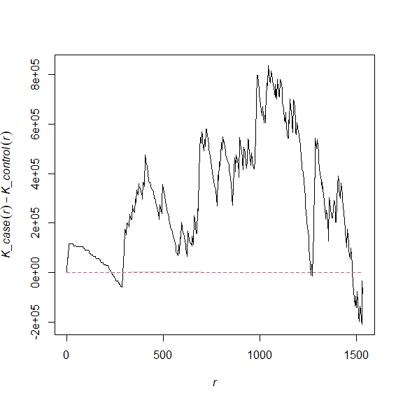

```r
plot(kd, cbind(iso, theo) ~ r, legend = FALSE, main = "")
```

To investigate where $\widehat{KD}(r)$ differs significantly from zero, tolerance envelopes for $KD(r)$ can be estimated by simulating data under the random labeling hypothesis. We need to specify:

- `nsim`: the number of randomly labeled data sets to generate.
- `level`: the level of the tolerance envelopes. The default is `0.90`.

When `nsim>0`, the `kdest` function returns an object of class `kdenv`. `print`, `summary`, and `plot` methods are defined for `kdenv` objects. The `print` method will print information about the `kdenv` object, `summary` will summarize the distances at which $\widehat{KD}(r)$ is outside the tolerance envelopes, and `plot` will plot $\widehat{KD}(r)$ versus $r$, along with the average $\widehat{KD}(r)$ for data sets simulated under the null hypothesis, the tolerance envelopes, and envelopes of the minimum and maximum $\widehat{KD}(r)$ for the simulated data sets.

We contruct tolerance envelopes for $KD(r)$ based on 49 data sets simulated under the random labeling hypothesis at the 0.95 level. Using the output of the `summary` function, we see that $\widehat{KD}(r)$ is outside the tolerance envelopes for $r$ in the (approximate) intervals, 9-48, 353-387, 395-425, 985-1004, 1081-1085, and at $r=1090.454$. The corresponding plot is shown below with a manual legend created to identify the various parts of the plot.

```r
kdenv <- kdest(grave, case = "affected", nsim = 49,
              level = 0.95)
```

```
## affected has been selected as the case group
```

```
## Generating 49 simulations by evaluating expression  ...
## 1, 2, 3, 4, 5, 6, 7, 8, 9, 10, 11, 12, 13, 14, 15, 16, 17, 18, 19, 20,
## 21, 22, 23, 24, 25, 26, 27, 28, 29, 30, 31, 32, 33, 34, 35, 36, 37, 38, 39, 40,
## 41, 42, 43, 44, 45, 46, 47, 48,
## 49.
##
## Done.
```

```r
# print some information about kdenv
print(kdenv)
```

```
##
## Envelopes for difference in estimated K functions
##
## KD(r) = K_case(r) - K_control(r)
## case label:  affected
## control label:  unaffected
## KD(r) computed for r betwen  0 and 1533.825
## number of simulations:  49
## simulation procedure: random labeling
## envelope level:  0.95
```

```r
# determine distances KD(r) outside tolerance envelopes
summary(kdenv)
```

```
## KD(r) > upper envelope limit for the following r:
## 8.987257 to 47.93204
## 353.4988 to 386.4521
## 395.4393 to 425.3968
## 985.6025 to 1003.577
## 1081.467 to 1084.462
## 1090.454
```

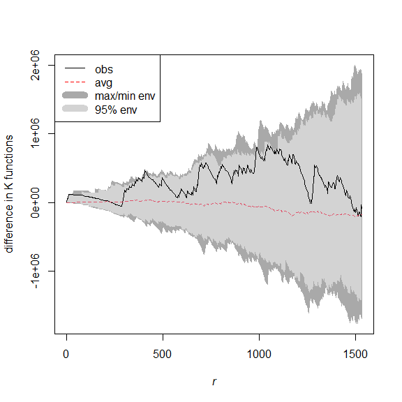

```r
# plot results
plot(kdenv, ylab = "difference in K functions")
legend("topleft", legend = c("obs", "avg", "max/min env", "95% env"),
       lty = c(1, 2, 1, 2), col = c("black", "red", "darkgrey", "lightgrey"),
       lwd = c(1, 1, 10, 10))
```

The tolerance envelopes do not account for multiple comparisons, so Diggle and Chetwynd (1991) proposed a test of

$H_0: KD(r) = 0$ for all $r$ in $[0, r_{max}]$

$H_a: KD(r) > 0$ for at least one $r$ in $[0, r_{max}]$

using the test statistic $KD_+=\sum_{i=1}^m \widehat{KD}(r_i)$, where $r_1,\ldots,r_m$ are the sequence of values for which $\widehat{KD}(r)$ is estimated.

This test is implemented in the `kdplus.test` function.

For the `grave` data, since the p-value is somewhat small (0.06), there is weak evidence that the affected grave locations are clustered relative to the unaffected grave locations for some distance between 0 and 1533 meters.

```r
kdplus.test(kdenv)
```

```
##
## Diggle and Chetwynd (1991) test for difference in K functions
##
## KD(r) = K_case(r) - K_control(r)
## case label:  affected
## control label:  unaffected
##
## null hypothesis: KD(r) = 0 for all r between 0 and 1533.825
## alternative hypothesis: KD(r) > 0 for at least one r between 0 and 1533.825
## test statistic: 576.2432
## p-value: 0.06
## nsim: 49
## simulation procedure: random labeling
```

## Spatial scan test

Kulldorff (1997) proposed a spatial scan test for case-control point data. The test scans the study area using circular windows to identify windows with unusual collections of cases compared to what is outside the window. The significance of the most likely cluster (window) is assessed via the random labeling hypothesis. The test is implemented using the `spscan.test` function, which takes the arguments:

- `x`: a `ppp` object with `marks` for the cases and controls
- `case`: a character string specifying the name of the case group or the index of the case group in `levels(x$marks)`. The default is `case = 2`, the second level of `x$marks`.
- `nsim`: the number of randomly labeled data sets to generate.
- `alpha`: the significance level of the test
- `maxd`: the maximum size of the window. the default is half the maximum inter-event distance.

The method assess whether the most likely cluster of cases is significant under the random labeling hypothesis. It can also be used to identify the most likely clusters of events that do not overlap.

The `print` function will summarize some basic information of the test. The `summary` function will summarize any identified clusters. The `clusters` function will extract the events comprising the significant clusters. The `plot` function will draw the most likely and any secondary clusters.

For the `grave` data, we identify one significant cluster. The cluster is centered at $(10324, 4389)$ with a radius of 1359.7 meters and includes 19 events (11 affected graves). The cluster was found on the lower right part of the study area. The cluster includes events 126, 124, …, 75.

```r
scan = spscan.test(grave, nsim = 49, case = "affected")
```

```
## affected has been selected as the case group
```

```r
# print info about scan
scan
```

```
## method: circular scan
## distance upperbound:  3689.4017468961
## realizations: 49
```

```r
# summary of scan test results
summary(scan)
```

```
##   centroid_x centroid_y radius events cases ex  rr stat   p
## 1      10324       4389 1359.7     19    11  4 3.8  7.4 0.1
```

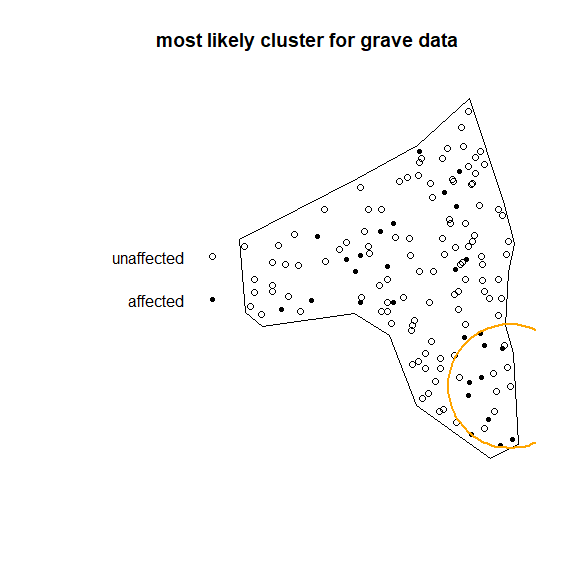

```r
# plot scan test results
plot(scan, chars = c(1, 20), main = "most likely cluster for grave data",
     border = "orange")
```

```r
# extract most likely and other significant clusters
clusters(scan)
```

```
## [[1]]
##  [1] 126 124 125 132 120 113 140 141 112  41 136  30 133 108  31 143 110 139  75
```

## Q nearest neigbors

Cuzick and Edwards (1990) proposed a test to examine whether the number of cases within the $Q$ nearest neighbors of other cases is unusually large relative to the random labeling hypothesis. This test is implemented in the `qnn.test` function, which takes the arguments:

- `x`: a `ppp` object with `marks` for the cases and controls
- `q`: a sequence of $Q$ values to consider
- `case`: a character string specifying the name of the case group or the index of the case group in `levels(x$marks)`. The default is `case = 2`, the second level of `x$marks`.
- `nsim`: the number of randomly labeled data sets to generate.

Note that the statistics for different $Q$ will be correlated since, for example, the 3 nearest neighbors of a case will be included in the 5 nearest neighbors of a case. Thus, the test also measures the significance of the excess number of cases for different values of $Q$, i.e., the contrast between the test statistic for different values of $Q$. If the contrast is not significant, then any clustering observed is caused by the clustering observed for the smaller value of $Q$.

```r
qnn.test(grave, q = c(3, 5, 7, 9, 11, 13, 15), nsim = 49, case = "affected")
```

```
## affected has been selected as the case group
```

```
## Q nearest neighbors test
##
## case label:  affected
## control label:  unaffected
##
## Summary of observed test statistics
##
##   q  Tq pvalue
##   3  32   0.02
##   5  45   0.04
##   7  58   0.04
##   9  73   0.04
##  11  91   0.04
##  13 109   0.02
##  15 122   0.06
##
## Summary of observed contrasts between test statistics
##
##   contrast Tcontrast pvalue
##    T5 - T3        13   0.54
##    T7 - T3        26   0.46
##    T9 - T3        41   0.26
##   T11 - T3        59   0.16
##   T13 - T3        77   0.14
##   T15 - T3        90   0.12
##    T7 - T5        13   0.42
##    T9 - T5        28   0.28
##   T11 - T5        46   0.14
##   T13 - T5        64   0.10
##   T15 - T5        77   0.12
##    T9 - T7        15   0.20
##   T11 - T7        33   0.08
##   T13 - T7        51   0.08
##   T15 - T7        64   0.10
##   T11 - T9        18   0.10
##   T13 - T9        36   0.06
##   T15 - T9        49   0.10
##  T13 - T11        18   0.08
##  T15 - T11        31   0.16
##  T15 - T13        13   0.46
```

## References

Cuzick, J., and Edwards, R. (1990). Spatial clustering for inhomogeneous populations. Journal of the Royal Statistical Society. Series B (Methodological), 73-104.

Diggle, Peter J., and Amanda G. Chetwynd. “Second-order analysis of spatial clustering for inhomogeneous populations.” Biometrics (1991): 1155-1163.

Kelsall, Julia E., and Peter J. Diggle. “Non-parametric estimation of spatial variation in relative risk.” Statistics in Medicine 14.21-22 (1995): 2335-2342.

Kulldorff, M. (1997) A spatial scan statistic. Communications in Statistics – Theory and Methods 26, 1481-1496.